# PREPROCESADO DE DATOS - MÓDULO 1 - Marta Pellicer Navarro

A continuación buscamos satisfacer los siguientes puntos requeridos por el enunciado de la tarea:

- Analice la relación entre las variables demográficas, el estilo de vida, el historial médico y los síntomas con el diagnóstico de la enfermedad de Parkinson.
- Realiza un análisis de correlación entre los factores de riesgo como el índice de masa corporal (BMI), el consumo de alcohol y el historial médico (hipertensión, diabetes, etc.) con la presencia de la enfermedad.

**Variables demográficas:**

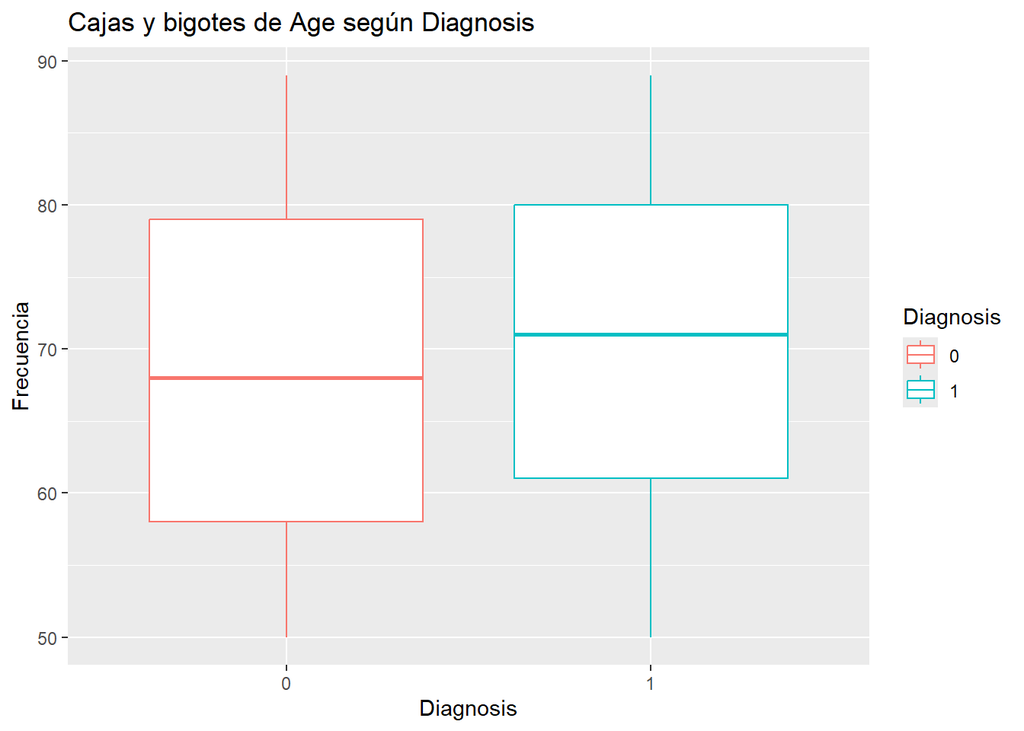

```r
age_diagnosis <- boxplot_var_target_plot(df, "Age", "Diagnosis")

print(age_diagnosis)
```

```r
genderDiag = table(df$Gender, df$Diagnosis)
colnames(genderDiag) = c("Sin Parkinson", "Con Parkinson")
rownames(genderDiag) = c("Hombre", "Mujer")
print(genderDiag)
```

[output not shown]

Como podemos ver en la tabla de frecuencias anterior, aparentemente el padecer o no la enfermedad de Parkinson no depende del género.

```r
etniaDiag = table(df$Ethnicity, df$Diagnosis)
colnames(etniaDiag) = c("Sin Parkinson", "Con Parkinson")
rownames(etniaDiag) = c("Caucásico", "Afroamericano", "Asiático", "Otro")
etniaDiag
```

```
##
##                 Sin Parkinson Con Parkinson
##   Caucásico               490           780
##   Afroamericano           150           275
##   Asiático                 73           124
##   Otro                     88           125
```

A la vista de la tabla de frecuencias anterior, si calculamos las probabilidades de padecer Parkinson en función de la procedencia del paciente obtenemos los siguientes: caucásico ($62\%$), afroamericano ($65\%$), asiático ($63\%$) y otro ($59\%$). Estrictamente, podríamos decir que las personas con procedencia afroamericana tienen una probabilidad ligeramente superior de padecer Parkinson con respecto a las otras etnias.

De este análisis demográfico concluimos que el género no es un factor determinante para padecer o no Parkinson, sin embargo, existe una ligera probabilidad de que los individuos de origen afroamericano padezcan con más frecuencia la enfermedad.

```r
fumaDiag = table(df$Smoking, df$Diagnosis)
colnames(fumaDiag) = c("Sin Parkinson", "Con Parkinson")
rownames(fumaDiag) = c("No fuma", "Sí fuma")
fumaDiag
```

```
##
##           Sin Parkinson Con Parkinson
##   No fuma           566           915
##   Sí fuma           235           389
```

Vemos en la tabla de frecuencias que la proporción en ambos casos se mantiene. La probabilidad de padecer Parkinson siendo fumador es del $62\%$ y la probabilidad de padecer Parkison siendo no fumador es del $61\%$ por lo tanto concluimos que, en este caso, no depende de si el paciente es o no fumador.

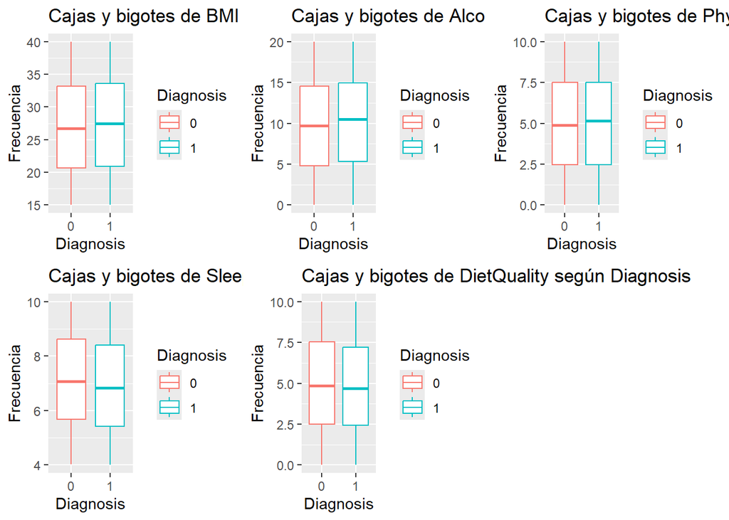

```r
bmi_diagnosis <- boxplot_var_target_plot(df, "BMI", "Diagnosis")
alcohol_diagnosis <- boxplot_var_target_plot(df, "AlcoholConsumption", "Diagnosis")
actfisica_diagnosis <- boxplot_var_target_plot(df, "PhysicalActivity", "Diagnosis")
dieta_diagnosis <- boxplot_var_target_plot(df, "DietQuality", "Diagnosis")
suegno_diagnosis <- boxplot_var_target_plot(df, "SleepQuality", "Diagnosis")

grid.arrange(bmi_diagnosis, alcohol_diagnosis, actfisica_diagnosis, suegno_diagnosis, dieta_diagnosis,
             nrow = 2, ncol=3)
```

En el eje X de las cinco representaciones gráficas tenemos represantado el padecer (1) o no (0) la enfermedad. Como podemos observar los factores relativos al estilo de vida de las personas, en principio, no son determinantes a padecer o no la enfermedad.